# Задача обучения без учителя.

## Кластеризация (Unsupervised learning)

**Дано:**  
$X$ - пространство объектов;  
$\{x_1, \ldots, x_l\}\subset X$ - обучающая выборка (training sample);  
$\rho: X\times X\rightarrow[0,\infty)$ - функция расстояний между объектами.

**Найти:**  
$Y$ - множество кластеров; $a: X\rightarrow Y$ - алгоритм кластеризации такой, что:

- каждый кластер состоит из близких объектов;
- объекты разных кластеров существенно различны.

Кластеризация - обучения без учителя.

Решение задачи неоднозначно в силу следующих причин:

- нет точной постановки задачи;
- существуют разные критерии качества кластеризации;
- существуют множество эвристических методов кластеризации;
- число кластеров, как правило, неизвестно заранее;
- результат кластеризации зависит от метрики.

## Цели кластеризации

- Упростить дальнейшую обработку данных. Разбить обучающую выборку на схожие группы, чтобы в дальнейшем работать с каждой группой отдельно.

[figure not shown]

- Сократить объем хранимых данных. Оставить по одному представителю от каждого кластера.

[figure not shown]

- Выделить нетипичные объекты. Определить выбросы.

[figure not shown]

- Построить иерархию множества объектов.

[figure not shown]

## Типы кластерных структур

Сгустки

[figure not shown]

Ленточные кластеры

[figure not shown]

Кластеры с перемычками

[figure not shown]

Кластеры с шумом

[figure not shown]

Перекрывающиеся кластеры

[figure not shown]

Искусственные кластеры

[figure not shown]

Кластеры могут отсутствовать

[figure not shown]

- Каждый метод кластеризации имеет свои особенности и работает только с определенным типов кластеров.
- Понятие "тип кластера" не имеет четкого определения.
- Нормировка признаков может влиять на кластеризацию.

[figure not shown]

## Частичное обучение (Semi-supervised learning)

**Дано:**  
$X$ - пространство объектов;  
$Y$ - пространство ответов;  
$\{x_1, \ldots, x_l\}\subset X$ - обучающая выборка (training sample);  
$\{y_1, \ldots, y_k\}\subset Y$ - ответы на части объектов;  
$\rho: X\times X\rightarrow[0,\infty)$ - функция расстояний между объектами.

**Найти:**  
$a: X\rightarrow Y$ - алгоритм классификации;  
*ИЛИ*  
$\{y_ {k+1}, \ldots, y_l\}$ - ответы на неразмеченных объектах.

[figure not shown]

## Оценка качества кластеризации

### Оценка при известных метках классов

[Homogeneity и Completeness](http://scikit-learn.org/stable/modules/clustering.html#homogeneity-completeness-and-v-measure)

- *homogeneity*: мера того, что каждый кластер содержит только элементы одного класса.
- *completeness*: мера того, что все элементы одного класса попали в один кластер.
- *V-measure*: среднее гармоническое двух мер.

```python
y_true = [0, 0, 0, 1, 1, 1, 2, 2, 2]
y_pred = [5, 5, 5, 6, 6, 6, 7, 7, 7]
print(homogeneity_score(y_true, y_pred))
print(completeness_score(y_true, y_pred))
print(v_measure_score(y_true, y_pred))
```

```
1.0
1.0
1.0
```

```python
y_true = [0, 0, 0, 1, 1, 1, 2, 2, 2]
y_pred = [5, 5, 5, 5, 5, 5, 7, 7, 7]
print(homogeneity_score(y_true, y_pred))
print(completeness_score(y_true, y_pred))
print(v_measure_score(y_true, y_pred))
```

```
0.579380164286
1.0
0.733680436651
```

```python
y_true = [0, 0, 0, 0, 0, 0, 0, 0, 0]
y_pred = [5, 5, 5, 6, 6, 6, 7, 7, 7]
print(homogeneity_score(y_true, y_pred))
print(completeness_score(y_true, y_pred))
print(v_measure_score(y_true, y_pred))
```

```
1.0
3.03170564195e-16
6.06341128391e-16
```

[figure not shown]

[Adjusted Rand index](http://scikit-learn.org/stable/modules/clustering.html#adjusted-rand-index)

[статья на вики](https://en.wikipedia.org/wiki/Rand_index)

**Rand index**

Пусть дано множество $S = \{o_1, \ldots, o_n\}$, а также два его разбиения на подмножества $X = \{X_1, \ldots, X_r\}$ и $Y = \{Y_1, \ldots, Y_s\}$. Обозначим:

- $a$ - число пар элементов из $S$, которые лежат в одном подмножестве в $X$ и в одном подмножестве в $Y$;
- $b$ - число пар элементов из $S$, которые лежат в разных подмножествах в $X$ и в разных подмножествах в $Y$;
- $c$ - число пар элементов из $S$, которые лежат в одном подмножестве в $X$ и в разных подмножествах в $Y$;
- $d$ - число пар элементов из $S$, которые лежат в разных подмножествах в $X$ и в одном подмножестве в $Y$.

Тогда $$ R = \frac{a+b}{a+b+c+d} = \frac{a+b}{{n \choose 2 }} $$

$n_{ij}=\big|X_i\cap Y_i\big|$

[figure not shown]

$$ \text{AdjustedIndex} = \frac{\text{Index} - \text{ExpectedIndex}}{\text{MaxIndex} - \text{ExpectedIndex}} $$$$ ARI = \frac{ \sum_{ij} \binom{n_{ij}}{2} - [\sum_i \binom{a_i}{2} \sum_j \binom{b_j}{2}] / \binom{n}{2} }{ \frac{1}{2} [\sum_i \binom{a_i}{2} + \sum_j \binom{b_j}{2}] - [\sum_i \binom{a_i}{2} \sum_j \binom{b_j}{2}] / \binom{n}{2} } $$

### Оценка при неизвестных метках классов

- Среднее внутрикластерное расстояние: $$ F_0 = \frac{\sum_{i\lt j}[y_i=y_j]\rho(x_i, x_j)}{\sum_{i\lt j}[y_i=y_j]}\rightarrow \min $$
- Среднее межкластерное расстояние: $$ F_1 = \frac{\sum_{i\lt j}[y_i\neq y_j]\rho(x_i, x_j)}{\sum_{i\lt j}[y_i\neq y_j]}\rightarrow \max $$
- Отношение пары функционалов: $$ F_0 / F_1 \rightarrow \min $$

В случае, если объекты задаются наборами признаков, можно рассмотреть следующие функционалы:

- Сумма средних внутрикластерных расстояний: $$ G_0 = \sum_{y\in Y}\frac{1}{|K_y|}\sum_{i: y_i=y}\rho(x_i, \mu_y)\rightarrow\min, $$ $K_y$ - кластер $y$, $\mu_y$ - центр масс кластера $y$.
- Сумма межкластерных расстояний: $$ G_1 = \sum_{y, z\in Y}\rho(\mu_y, \mu_z)\rightarrow\max, $$
- Отношение пары функционалов: $$ G_0 / G_1 \rightarrow \min $$

**Кластеризация как задача дискретной оптимизации**

Пусть $w_{ij} = \exp\big(-\beta \rho(x_i, x_j)\big)$, $\beta$ - некоторый параметр.

Задача кластеризации: $$ \sum_{i=1}^l\sum_{j=i+1}^l w_{ij}[a_i\neq a_j]\rightarrow \min_{a_i\in Y} $$

Задача частичного обучения: $$ \sum_{i=1}^l\sum_{j=i+1}^l w_{ij}[a_i\neq a_j] + \lambda\sum_{i=1}^k[a_i\neq y_i]\rightarrow \min_{a_i\in Y}, $$

где $\lambda$ - еще один параметр.

# Алгоритмы кластеризации

## k-means

*Идея:* Выбираются несколько точек $\{\mu_y\}$ таких, что они минимизируют сумму квадратов внутрикластерных расстояний.

$$ \sum_{y\in Y}\sum_{x_i\in K_y}\sum_{j=1}^m\big(f_j(x_i)-\mu_{yj}\big)^2\rightarrow\min_{\mu_y} $$

[figure not shown]

[Наглядно](https://www.naftaliharris.com/blog/visualizing-k-means-clustering/)  
[Реализация](http://scikit-learn.org/stable/modules/generated/sklearn.cluster.KMeans.html)

**Частичное обучение:** размеченные объекты не меняют класс.

- Легко интерпретируется;
- Результат сильно зависит от начального расположения центров кластеров;
- Необходимо задавать число кластеров;
- Результат зависит от нормировки признаков.

*Замечание:* в случае, если точки заданы попарными расстояниями, можно в качестве центра кластера выбирать не $\frac{1}{|K|}\sum_{x_i\in K}x_i$, а $\arg\min_{x\in K}\sum_{x_i\in K}\rho(x_i, x)$.

## КНП (Кратчайший Незамкнутый Путь)

Для $l$ точек ищем $l-1$ ребро, обладающих наименьшей суммарной длиной. Проводим эти ребра, а потом удаляем $K-1$ самых длинных ребер.

[figure not shown]

**Частичное обучение:** Пока есть пути между вершинами разных классов - удаляем самое длинное ребро на этих путях.

- Легко интерпретируется;
- Необходимо задавать число кластеров;
- Чувствительность к шуму.

## FOREL

*Первая стадия:* по одному раскидываем по пространству признаков центроиды и стабилизируем их (как в *KMeans*).  
*Вторая стадия:* применяем КНП к центроидам.

[figure not shown]

- Легко интерпретируется;
- Число кластеров подбирается алгоритмом;
- Кластеризация зависит от выбора ядра;
- Двухуровневая стуктура кластеров;
- Кластеры могут быть произвольной формы;
- Устойчивость к шуму;
- Кластеризация зависит от случайного выбора начальных точек.

## DBSCAN

[figure not shown]

DBSCAN(*D*, *eps*, *MinPts*) {  
$\ \ \ $*C* = 0  
$\ \ \ $**for each** point *P* in dataset *D* {  
$\ \ \ \ \ \ $**if** *P* is visited  
$\ \ \ \ \ \ \ \ \ $**continue** next point  
$\ \ \ \ \ \ $mark *P* as visited  
$\ \ \ \ \ \ $*NeighborPts* = region(*P*, *eps*)  
$\ \ \ \ \ \ $**if** sizeof(*NeighborPts*) < *MinPts*  
$\ \ \ \ \ \ \ \ \ $mark *P* as NOISE  
$\ \ \ \ \ \ $**else** {  
$\ \ \ \ \ \ \ \ \ $*C* = next cluster  
$\ \ \ \ \ \ $expandCluster(*P*, *NeighborPts*, *C*, *eps*, *MinPts*)  
$\ \ \ \ \ \ $}  
$\ \ \ $}  
}

expandCluster(*P*, *NeighborPts*, *C*, *eps*, *MinPts*) {  
$\ \ \ $add *P* to cluster *C*  
$\ \ \ $**for each** point *P'* in *NeighborPts* {  
$\ \ \ \ \ \ $**if** *P'* is not visited {  
$\ \ \ \ \ \ \ \ \ $mark *P'* as visited  
$\ \ \ \ \ \ \ \ \ $*NeighborPts'* = region(*P'*, *eps*)  
$\ \ \ \ \ \ \ \ \ $**if** sizeof(*NeighborPts'*) >= *MinPts*  
$\ \ \ \ \ \ \ \ \ \ \ \ $*NeighborPts* = *NeighborPts* joined with *NeighborPts'*  
$\ \ \ \ \ \ $}  
$\ \ \ \ \ \ $**if** *P'* is not yet member of any cluster  
$\ \ \ \ \ \ \ \ \ $add *P'* to cluster *C*  
$\ \ \ $}  
}

**Особенности:**

- не требует задания числа кластеров;
- ищет кластеры любой формы;
- устойчив к шуму;
- имеет только 2 параметра;
- недетерминирован;
- плохо работает в случае кластеров разных плотностей;
- может плохо работать в случае кластеров с перемычками.

[figure not shown]

[Наглядно](https://www.naftaliharris.com/blog/visualizing-dbscan-clustering/)

[Реализация](http://scikit-learn.org/stable/modules/generated/sklearn.cluster.DBSCAN.html)

Эвристики при подборе параметров:

- подбирайте *min_samples* от 3 до 9: чем более неоднородный ожидается датасет, и чем больше уровень шума, тем большим следует взять *min_samples*.
- в качестве *eps* можно взять значение, лежащее в полосе, где график отсортированного среднего расстояния по *m* ближайшим соседям имеет наибольший изгиб.

[figure not shown]

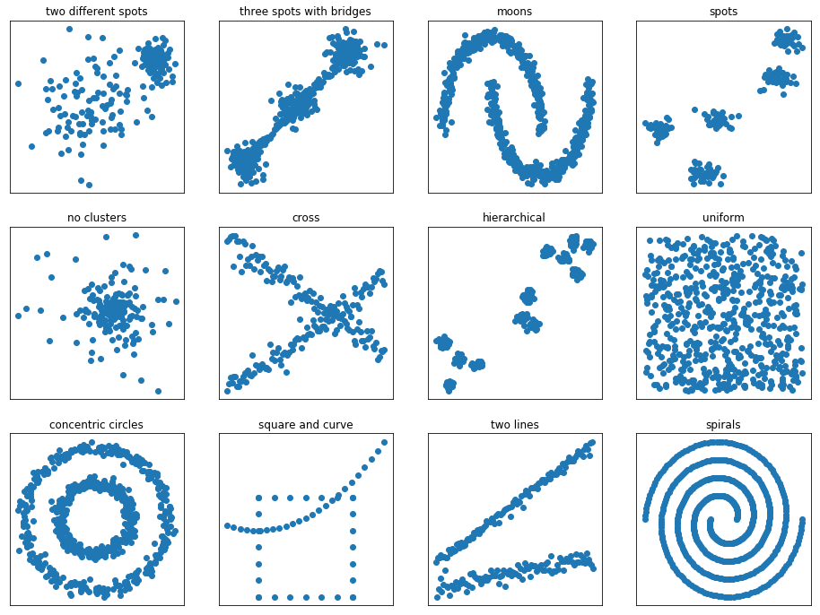

```python
show_plots(samples, False)
```

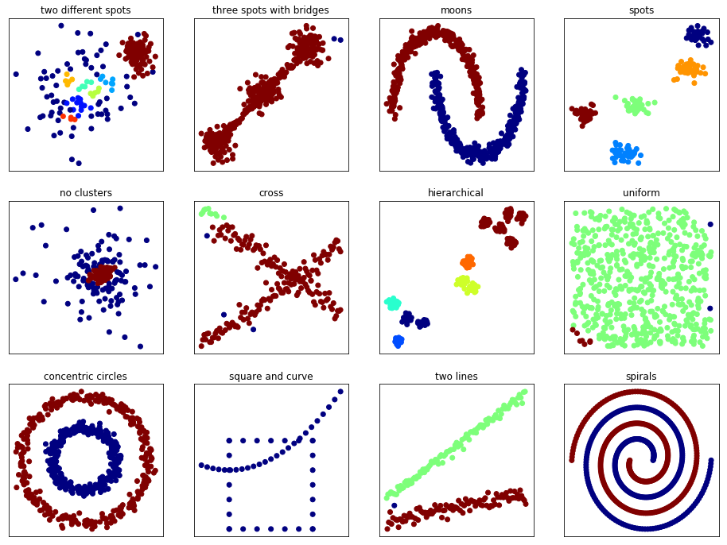

```python
show_plots(samples, True)
```

## Affinity propagation

*Интуитивное объяснение.*

- $S$ - матрица "похожести"; чем больше $S_{ij}$, тем больше $i$-ый и $j$-ый объекты похожи.
- $R$ - матрица "ответственности"; $R_{ij}$ - мера того, насколько $i$ хочет видеть $j$ своим представителем.
- $A$ - матрица "доступности"; $A_{ij}$ - мера того, насколько $j$ готова быть представлителем $i$.

Изначально $R$ и $A$ - нулевые.

$$ \forall i, k:\ r(i,k) \leftarrow s(i,k) - \max_{k' \neq k} \left\{ a(i,k') + s(i,k') \right\} $$$$ \forall i, k:\ a(i,k) \leftarrow \min \left( 0, r(k,k) + \sum_{i' \not\in \{i,k\}} \max(0, r(i',k)) \right) $$$$ \forall k:\ a(k, k) \leftarrow \sum_{i' \neq k} \max(0, r(i',k)) $$

$$ \forall i:\ c_i \leftarrow \arg\max_k\big(a(i, k) + r(i, k)\big) $$

[figure not shown]

[Понятное описание алгоритма](https://habrahabr.ru/post/321216/)

[Реализация](http://scikit-learn.org/stable/modules/generated/sklearn.cluster.AffinityPropagation.html)

## Mean Shift

[figure not shown]

$$ m(x) = \frac{\sum_{i}K(x_i, x)x_i}{\sum_{i}K(x_i, x)} $$$$ K(x, x') = \exp(-c||x - x'||^2) $$

[figure not shown]

- Легко интерпретируется;
- Число кластеров подбирается алгоритмом;
- Кластеризация зависит от параметров ядра;
- Плохо работает с кластерами сложной формы.

[Реализация](http://scikit-learn.org/stable/modules/generated/sklearn.cluster.MeanShift.html)

## Алгоритм Ланса-Уильямса (иерархическая кластеризация)

*Идея:* поэтапно объединять наиболее близкие кластеры.

1. $t:=0, C_t=\big\{\{x_1\}, \ldots, \{x_n\}\big\}$;
2. for $t$ in $1, \ldots, n-1$:
3. $\ \ \ \ \ $for all $S\in C_{t-1}$:
4. $\ \ \ \ \ $$\ \ \ \ \ $calculate $R(W, S)$;
5. $\ \ \ \ \ $find in $C_{t-1}$ two nearest clusters: $(U,V):=\arg\min_{U\neq V}R(U, V)$;
6. $\ \ \ \ \ $merge these clusters $W:=U\cup V$; $C_t:=C_{t-1}\cup\{W\}\setminus \{U, V\}$.

**Частичное обучение:** объединяем кластера, только если там нет объектов с разными метками.

[figure not shown]

| расстояние ближайшего соседа $R_{б}$ | расстояние дальнего соседа $R_{д}$ | среднее попарное расстояние $R_{с}$ |
| --- | --- | --- |

| $R_{ц}=\rho(\mu_U, \mu_V)$ | $R_{у}=\frac{\mid U\mid\mid V\mid}{\mid U\mid+\mid V\mid}\rho(\mu_U, \mu_V)$ |
| --- | --- |
| расстояние между центрами $R_{ц}$ | расстояние Уорда $R_{у}$ |

### Как выбрать функцию расстояния?

- *Монотонность:* $R_2\le R_3 \le \ldots \le R_{n}$.
- *Расстягивающее отображение:* $R_t \ge \rho(\mu_U, \mu_V),\ \forall t$.
- *Стягтивающее отображение:* $R_t \le \rho(\mu_U, \mu_V),\ \forall t$.

Хотелось бы, чтобы отображение было монотонным и растягивающим.

$R_{ц}$ не монотонно; $R_{б}$, $R_{д}$, $R_{с}$, $R_{у}$ - монотонны.

$R_{б}$ - сжимающее; $R_{д}$, $R_{у}$ - растягивающее.

[Реализация](http://scikit-learn.org/stable/modules/generated/sklearn.cluster.AgglomerativeClustering.html)

[figure not shown]